# Converting Strings to Dates

R Vocab Topics » Dates » Converting strings to dates

- Convert strings to dates
- Create dates by merging data

## Convert Strings to Dates

To convert a string that is already in a date format (YYYY-MM-DD) into a date object use `as.Date()`:

```r
x <- c("2015-07-01", "2015-08-01", "2015-09-01")

as.Date(x)
```

```
## [1] "2015-07-01" "2015-08-01" "2015-09-01"
```

Note that the defaul date format is YYYY-MM-DD; therefore, if your string is of different format you must incorporate the `format` argument:

```r
y <- c("07/01/2015", "07/01/2015", "07/01/2015")

as.Date(y, format = "%m/%d/%Y")
```

```
## [1] "2015-07-01" "2015-07-01" "2015-07-01"
```

☛ *For a complete list of formatting codes: `?strftime`*

If using the `lubridate` package:

```r
library(lubridate)
ymd(x)
```

```
## [1] "2015-07-01 UTC" "2015-08-01 UTC" "2015-09-01 UTC"
```

```r
mdy(y)
```

```
## [1] "2015-07-01 UTC" "2015-07-01 UTC" "2015-07-01 UTC"
```

One of the many benefits of the `lubricate` package is that it automatically recognizes the common separators used when recording dates (“-”, “/”, “.”, and “”). As a result, you only need to focus on specifying the order of the date elements to determine the parsing function applied:

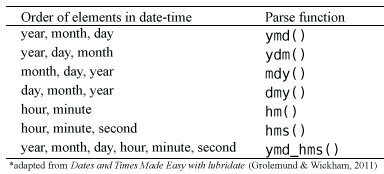

## Create Dates by Merging Data

Sometimes your date data are collected in separate elements. To convert these separate data into one date object incorporate the `ISOdate()` function:

```r
yr <- c("2012", "2013", "2014", "2015")
mo <- c("1", "5", "7", "2")
day <- c("02", "22", "15", "28")

# ISOdate converts to a POSIXct object
ISOdate(year = yr, month = mo, day = day)
```

```
## [1] "2012-01-02 12:00:00 GMT" "2013-05-22 12:00:00 GMT"
## [3] "2014-07-15 12:00:00 GMT" "2015-02-28 12:00:00 GMT"
```

```r
# truncate the unused time data by converting with as.Date
as.Date(ISOdate(year = yr, month = mo, day = day))
```

```
## [1] "2012-01-02" "2013-05-22" "2014-07-15" "2015-02-28"
```

Note that `ISODate()` also has arguments to accept data for hours, minutes, seconds, and time-zone if you need to merge all these separate components.

Go to top